# Project1_ql2273

# Introduction

U.S presidents’ inaugrual speeches are always hot topics after the ending of each presidential election. There are also a large amount of interesting points for text mining in the inaurgrual speeches. In this project, topics about length of sentences, clustering of emotions and wordclound will shown below.

```r
# load packages
library("rvest")
library("tibble")
library("qdap")
library("sentimentr")
library("gplots")
library("dplyr")
library("tm")
library("syuzhet")
library("factoextra")
library("beeswarm")
library("scales")
library("RColorBrewer")
library("RANN")
library("tm")
library("topicmodels")
source("D:/3rd Semester/ADS_Teaching-master/Tutorials/wk2-TextMining/lib/plotstacked.R")
source("D:/3rd Semester/ADS_Teaching-master/Tutorials/wk2-TextMining/lib/speechFuncs.R")

main.page <- read_html(x = "http://www.presidency.ucsb.edu/inaugurals.php")
# Get link URLs
# f.speechlinks is a function for extracting links from the list of speeches.
inaug=f.speechlinks(main.page)
lct <- Sys.getlocale("LC_TIME"); Sys.setlocale("LC_TIME", "C")
```

```
## [1] "C"
```

```r
as.Date(inaug[,1], format="%B %e, %Y")
```

```
##  [1] "1789-04-30" "1793-03-04" "1797-03-04" "1801-03-04" "1805-03-04"
##  [6] "1809-03-04" "1813-03-04" "1817-03-04" "1821-03-04" "1825-03-04"
## [11] "1829-03-04" "1833-03-04" "1837-03-04" "1841-03-04" "1845-03-04"
## [16] "1849-03-05" "1853-03-04" "1857-03-04" "1861-03-04" "1865-03-04"
## [21] "1869-03-04" "1873-03-04" "1877-03-05" "1881-03-04" "1885-03-04"
## [26] "1889-03-04" "1893-03-04" "1897-03-04" "1901-03-04" "1905-03-04"
## [31] "1909-03-04" "1913-03-04" "1917-03-04" "1921-03-04" "1925-03-04"
## [36] "1929-03-04" "1933-03-04" "1937-01-20" "1941-01-20" "1945-01-20"
## [41] "1949-01-20" "1953-01-20" "1957-01-21" "1961-01-20" "1965-01-20"
## [46] "1969-01-20" "1973-01-20" "1977-01-20" "1981-01-20" "1985-01-21"
## [51] "1989-01-20" "1993-01-20" "1997-01-20" "2001-01-20" "2005-01-20"
## [56] "2009-01-20" "2013-01-21" "2017-01-20" NA
```

```r
Sys.setlocale("LC_TIME", lct)
```

```
## [1] "Chinese (Simplified)_People's Republic of China.936"
```

```r
inaug=inaug[-nrow(inaug),] # remove the last line, irrelevant due to error.

inaug.list=read.csv("D:/3rd Semester/ADS_Teaching-master/Tutorials/wk2-TextMining/data/inauglist.csv", stringsAsFactors = FALSE)

inaug.list$type <- rep("inaug", nrow(inaug.list))
inaug.list=cbind(inaug.list, inaug)
```

```r
inaug$fulltext=NA
for(i in seq(nrow(inaug.list))) {
  text <- read_html(inaug.list$urls[i]) %>% # load the page
    html_nodes(".displaytext") %>% # isloate the text
    html_text() # get the text
  inaug.list$fulltext[i]=text
  # Create the file name
  filename <- paste0("D:/3rd Semester/ADS_Teaching-master/Tutorials/wk2-TextMining/data/fulltext/",
                     inaug.list$File[i], "-",
                     inaug.list$Term[i], ".txt")
  sink(file = filename) %>% # open file to write
  cat(text)  # write the file
  sink() # close the file
}
```

```r
## Generate List of Sentences
sentence.list=NULL
for(i in 1:nrow(inaug.list)){
  sentences=sent_detect(inaug.list$fulltext[i],
                        endmarks = c("?", ".", "!", "|",";"))
  if(length(sentences)>0){
    emotions=get_nrc_sentiment(sentences)
    word.count=word_count(sentences)
    #colnames(emotions)=paste0("emo.", colnames(emotions))
    # in case the word counts are zeros?
    emotions=diag(1/(word.count+0.01))%*%as.matrix(emotions)
    sentence.list=rbind(sentence.list,
                        cbind(inaug.list[i,-ncol(inaug.list)],
                              sentences=as.character(sentences),
                              word.count,
                              emotions,
                              sent.id=1:length(sentences)
                              )
    )
  }
}

sentence.list=
  sentence.list%>%
  filter(!is.na(word.count))

names(sentence.list)[1] <- "President"
```

# Length of sentences

The length of speeches and also the length of sentences in the speeches can will show us a brief perception of each speech. I use sentences as units of analysis for all these presidents’ speeches, and generate a plot showing numbers of words in a sentence each president used.

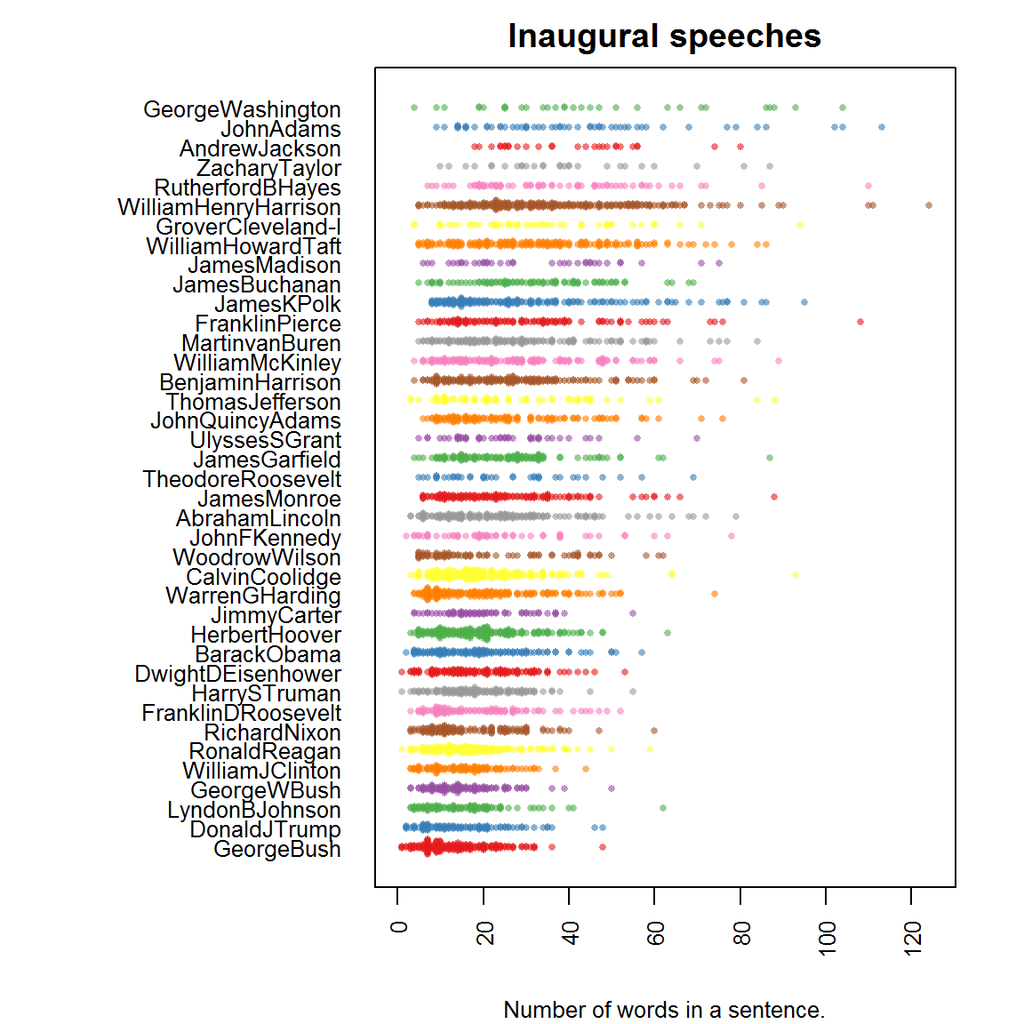

```r
## Length of sentences(First term)
par(mar=c(4, 11, 2, 2))

#sel.comparison=levels(sentence.list$FileOrdered)
sentence.list.sel=filter(sentence.list,
                        Term==1)
sentence.list.sel$File=factor(sentence.list.sel$File)

sentence.list.sel$FileOrdered=reorder(sentence.list.sel$File,
                                  sentence.list.sel$word.count,
                                  mean,
                                  order=T)

beeswarm(word.count~FileOrdered,
         data=sentence.list.sel,
         horizontal = TRUE,
         pch=16, col=alpha(brewer.pal(9, "Set1"), 0.6),
         cex=0.55, cex.axis=0.8, cex.lab=0.8,
         spacing=5/nlevels(sentence.list.sel$FileOrdered),
         las=2, xlab="Number of words in a sentence.", ylab="",
         main="Inaugural speeches")
```

As is shown above, it is not difficult to tell that president George Bush, Donald Trump, Lyndon Johnson, George W Bush and William Clinton are the top 5 presidents who would like to use short sentences in their inaugural speeches, while George Washington are most likely to use long sentences in his inaugural speech.

Here comes a question, what are those short sentences the top 5 presidents prefer to using?

```r
## Showing the sentences
sentence.list%>%
filter(File=="GeorgeBush",Term==1,word.count<=4)%>%
select(sentences)
```

```
##                          sentences
## 1                              Mr.
## 2               Chief Justice, Mr.
## 3          Help us remember, Lord.
## 4                            Amen.
## 5  in important things, diversity;
## 6       in all things, generosity.
## 7                 a loving parent;
## 8           We need to compromise;
## 9            we've had dissension.
## 10                We need harmony;
## 11                        Speaker.
## 12                Majority Leader.
## 13                      Thank you.
## 14                  God bless you.
```

```r
sentence.list%>%
filter(File=="DonaldJTrump",Term==1,word.count<=4)%>%
select(sentences)
```

```
##                     sentences
## 1 They have been magnificent.
## 2                  Thank you.
## 3           This is your day.
## 4   This is your celebration.
## 5              America first.
## 6           We will not fail.
## 7                  Thank you.
## 8                  Thank you.
## 9          God bless America.
```

```r
sentence.list%>%
filter(File=="LyndonBJohnson",Term==1,word.count<=3)%>%
select(sentences)
```

```
##                 sentences
## 1 It was self-government.
## 2        We say farewell.
```

```r
sentence.list%>%
filter(File=="GeorgeWBush",Term==1,word.count<=4)%>%
select(sentences)
```

```
##                 sentences
## 1         Thank you, all.
## 2 citizens, not subjects;
```

```r
sentence.list%>%
filter(File=="WilliamJClinton",Term==1,word.count<=3)%>%
select(sentences)
```

```
##                   sentences
## 1     Investment is mobile.
## 2 Americans deserve better.
```

# Emotion analysis

Besides the length of sentences, the emotion is an interesting part to analyze.

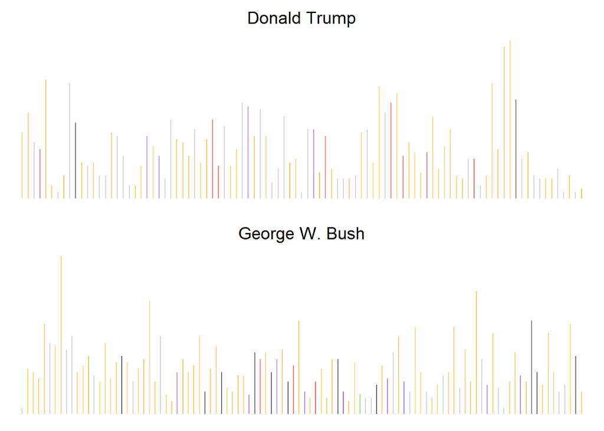

```r
par(mfrow=c(2,1), mar=c(1,0,2,0), bty="n", xaxt="n", yaxt="n", font.main=1)

f.plotsent.len(In.list=sentence.list, InFile="DonaldJTrump",
               InType="inaug", InTerm=1, President="Donald Trump")

f.plotsent.len(In.list=sentence.list, InFile="GeorgeWBush",
               InType="inaug", InTerm=1, President="George W. Bush")
```

The plot above shows us how presidents alternate between long and short sentences and how their emotion changes between different sentiments in their speeches. It is interesting to find out those sentences made emotion change as well.

```r
## emotionally changed sentences
print("Donald Trump")
```

```
## [1] "Donald Trump"
```

```r
speech.df=tbl_df(sentence.list)%>%
  filter(File=="DonaldJTrump", type=="inaug", Term==1, word.count>=5)%>%
  select(sentences, anger:trust)
speech.df=as.data.frame(speech.df)
as.character(speech.df$sentences[apply(speech.df[,-1], 2, which.max)])
```

```
## [1] "No challenge can match the heart and fight and spirit of America."
## [2] "God bless you, and God bless America."
## [3] "America will start winning again, winning like never before."
## [4] "No challenge can match the heart and fight and spirit of America."
## [5] "Today's ceremony, however, has very special meaning."
## [6] "America will start winning again, winning like never before."
## [7] "Today's ceremony, however, has very special meaning."
## [8] "God bless you, and God bless America."
```

```r
print("George W Bush")
```

```
## [1] "George W Bush"
```

```r
speech.df=tbl_df(sentence.list)%>%
  filter(File=="GeorgeWBush", type=="inaug", Term==1, word.count>=5)%>%
  select(sentences, anger:trust)
speech.df=as.data.frame(speech.df)
as.character(speech.df$sentences[apply(speech.df[,-1], 2, which.max)])
```

```
## [1] "Abandonment and abuse are not acts of God;"
## [2] "God bless you all, and God bless America."
## [3] "Where there is suffering, there is duty."
## [4] "Abandonment and abuse are not acts of God;"
## [5] "God bless you all, and God bless America."
## [6] "Abandonment and abuse are not acts of God;"
## [7] "Abandonment and abuse are not acts of God;"
## [8] "God bless you all, and God bless America."
```

For Donald Trump, the emotionally changed sentences are more like to be some inspiring slogans. While for George W Bush, the time he said sentences like “God bless you all” is the point he changed his emotions.

The emotion of the speech can be simply divided into two parts, positive and negative. Then I cluster these speeches into two groups.

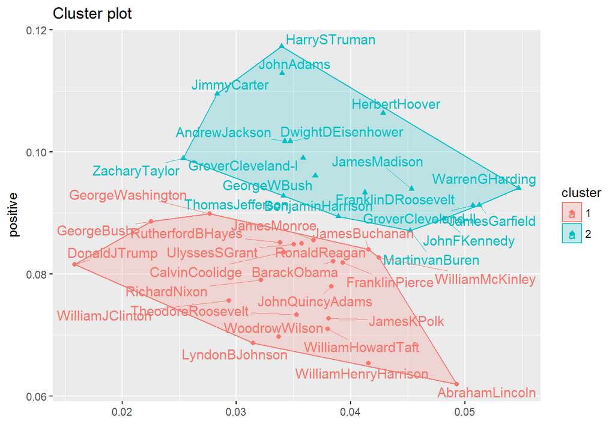

```r
## Clustering of emotions
presid.summary=tbl_df(sentence.list)%>%
  filter(type=="inaug")%>%
  #group_by(paste0(type, File))%>%
  group_by(File)%>%
  summarise(
    negative=mean(negative),
    positive=mean(positive)
  )

presid.summary=as.data.frame(presid.summary)
rownames(presid.summary)=as.character((presid.summary[,1]))
km.res=kmeans(presid.summary[,-1], iter.max=200,
              2)


fviz_cluster(km.res,
             stand=F, repel= TRUE,
             data = presid.summary[,-1], xlab="", xaxt="n",
             show.clust.cent=FALSE)
```

# Word Cloud

```r
##Wordcloud
library(tm)
library(wordcloud)
library(RColorBrewer)
library(dplyr)
library(tidytext)

folder.path="D:/3rd Semester/ADS_Teaching-master/Tutorials/wk2-TextMining/data/inaugurals/"
speeches=list.files(path = folder.path, pattern = "*.txt")
prex.out=substr(speeches, 6, nchar(speeches)-4)

ff.all<-Corpus(DirSource(folder.path))
```

```r
ff.all<-tm_map(ff.all, stripWhitespace)
ff.all<-tm_map(ff.all, content_transformer(tolower))
ff.all<-tm_map(ff.all, removeWords, stopwords("english"))
ff.all<-tm_map(ff.all, removeWords, character(0))
ff.all<-tm_map(ff.all, removePunctuation)

tdm.all<-TermDocumentMatrix(ff.all)

tdm.tidy=tidy(tdm.all)

tdm.overall=summarise(group_by(tdm.tidy, term), sum(count))
tdm.overall=tdm.overall[-1:-2,]
```

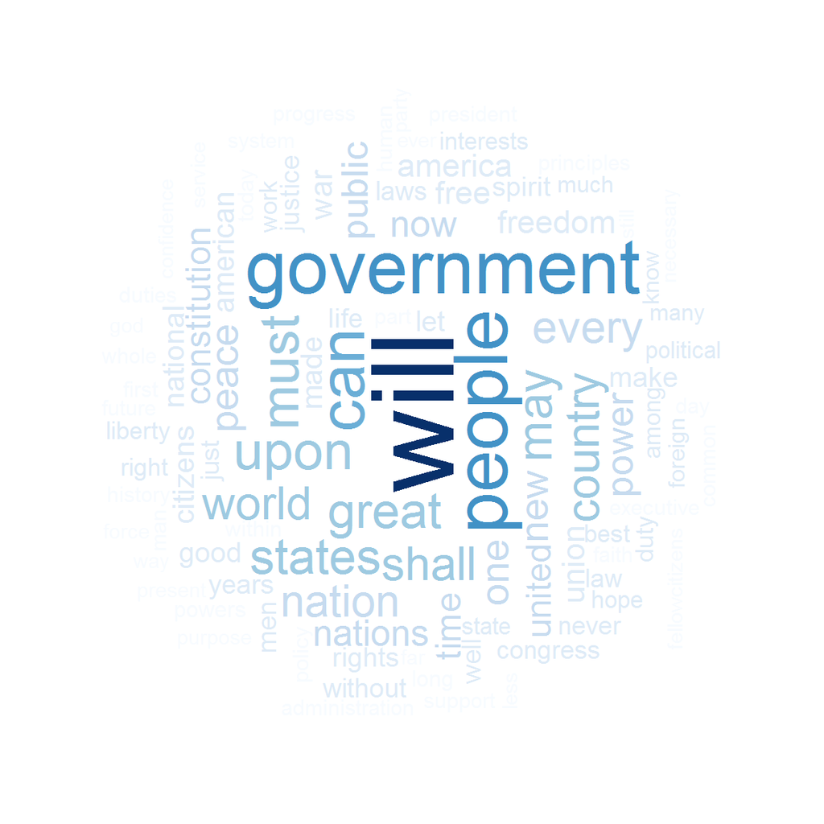

```r
wordcloud(tdm.overall$term, tdm.overall$`sum(count)`,
          scale=c(5,0.5),
          max.words=100,
          min.freq=1,
          random.order=FALSE,
          rot.per=0.3,
          use.r.layout=T,
          random.color=FALSE,
          colors=brewer.pal(9,"Blues"))
```

This is the overall word cloud from all speeches. We can see the most frequent words are related to countries and politics such as “government”, “people”, “country”, “freedom”. The strong affirmative words also play important roles such as “must”, “can”, “will”. In the next steps, we will look more details into seperate speeches.

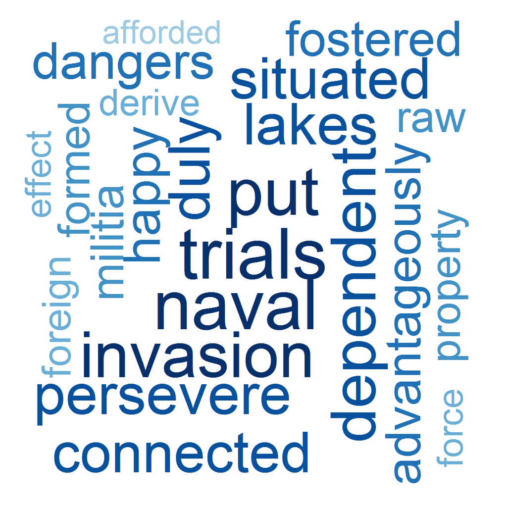

```r
dtm <- DocumentTermMatrix(ff.all,
                          control = list(weighting = function(x)
                                             weightTfIdf(x,
                                                         normalize =FALSE),
                                         stopwords = TRUE))
ff.dtm=tidy(dtm)
ff.dtm <- ff.dtm[-1:-2,]

type <- unique(ff.dtm$document)

jamesmonroe = ff.dtm[ff.dtm$document=="inaugJamesMonroe-1.txt",]
georgewbush = ff.dtm[ff.dtm$document=="inaugGeorgeWBush-2.txt",]
donaldtrump = ff.dtm[ff.dtm$document=="inaugDonaldJTrump-1.txt",]

# In 1817
wordcloud(jamesmonroe$term, jamesmonroe$count,
          scale=c(5,0.4),
          max.words=100,
          min.freq=1,
          random.order=FALSE,
          rot.per=0.3,
          use.r.layout=T,
          random.color=FALSE,
          colors=brewer.pal(9,"Blues"))
```

Word cloud for different presidents during different time period shows a strong relationship with events at that time.

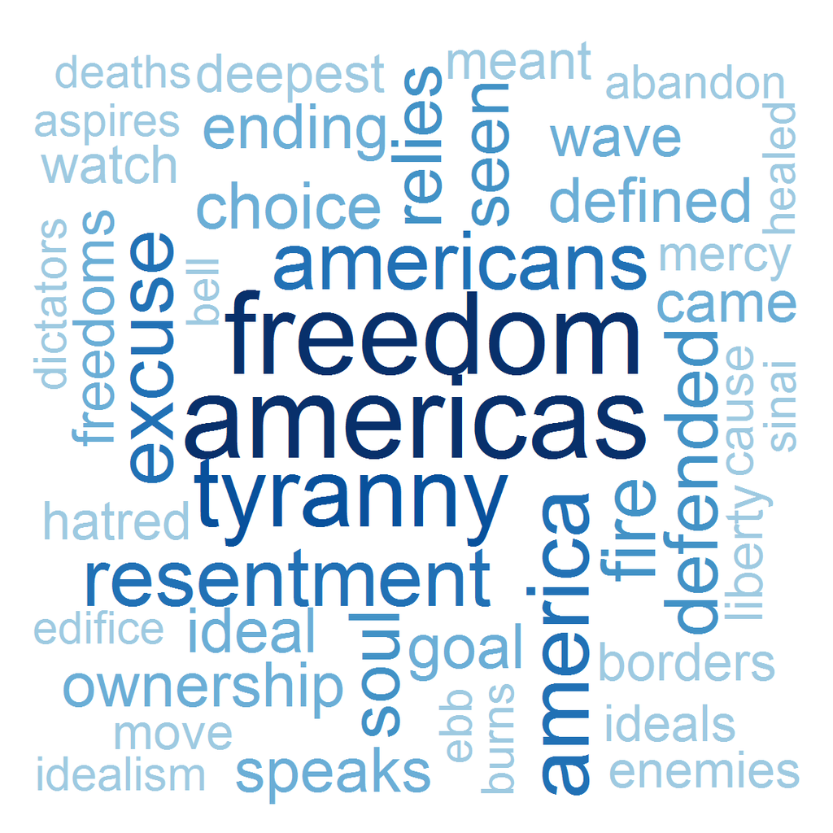

```r
# In year 2001
wordcloud(georgewbush$term, georgewbush$count,
          scale=c(5,0.4),
          max.words=100,
          min.freq=1,
          random.order=FALSE,
          rot.per=0.3,
          use.r.layout=T,
          random.color=FALSE,
          colors=brewer.pal(9,"Blues"))
```